# CS1_XG_DNN

```python
import numpy as np
import pandas as pd
import matplotlib.pyplot as plt
import seaborn as sns
from sklearn.model_selection import train_test_split
from sklearn.preprocessing import StandardScaler
from sklearn.impute import SimpleImputer
from imblearn.over_sampling import SMOTE
import matplotlib.pyplot as plt
import matplotlib.pyplot as plt
from sklearn.metrics import classification_report, accuracy_score, confusion_matrix, roc_curve, auc, RocCurveDisplay
import seaborn as sns
import warnings
warnings.filterwarnings('ignore')
```

```python
df=pd.read_csv('/content/MergedandCleaned1.csv')
df.head(1)
```

|  | review_id | user_id | business_id | review_stars | useful | funny | cool | text | review_date | business_name | ... | state | postal_code | latitude | longitude | business_stars | business_review_count | is_open | business_attributes | business_categories | business_hours |
| --- | --- | --- | --- | --- | --- | --- | --- | --- | --- | --- | --- | --- | --- | --- | --- | --- | --- | --- | --- | --- | --- |
| 0 | KU_O5udG6zpxOg-VcAEodg | mh_-eMZ6K5RLWhZyISBhwA | XQfwVwDr-v0ZS3_CbbE5Xw | 3 | 0 | 0 | 0 | If you decide to eat here, just be aware it is... | 2018-07-07 22:09:11 | Turning Point of North Wales | ... | PA | 19454 | 40.210196 | -75.223639 | 3.0 | 169.0 | 1.0 | {'NoiseLevel': "u'average'", 'HasTV': 'False',... | Restaurants, Breakfast & Brunch, Food, Juice B... | {'Monday': '7:30-15:0', 'Tuesday': '7:30-15:0'... |

1 rows × 22 columns

```python
df.info()
```

```
<class 'pandas.core.frame.DataFrame'>
RangeIndex: 18631 entries, 0 to 18630
Data columns (total 22 columns):
 #   Column                 Non-Null Count  Dtype
---  ------                 --------------  -----
 0   review_id              18631 non-null  object
 1   user_id                18631 non-null  object
 2   business_id            18631 non-null  object
 3   review_stars           18631 non-null  int64
 4   useful                 18631 non-null  int64
 5   funny                  18631 non-null  int64
 6   cool                   18631 non-null  int64
 7   text                   18631 non-null  object
 8   review_date            18631 non-null  object
 9   business_name          18631 non-null  object
 10  address                18525 non-null  object
 11  city                   18631 non-null  object
 12  state                  18631 non-null  object
 13  postal_code            18631 non-null  object
 14  latitude               18631 non-null  float64
 15  longitude              18631 non-null  float64
 16  business_stars         18631 non-null  float64
 17  business_review_count  18631 non-null  float64
 18  is_open                18631 non-null  float64
 19  business_attributes    18631 non-null  object
 20  business_categories    18631 non-null  object
 21  business_hours         18631 non-null  object
dtypes: float64(5), int64(4), object(13)
memory usage: 3.1+ MB
```

```python
irrelevant_columns = ['useful', 'funny', 'cool', 'text', 'review_date','review_id','user_id','latitude','longitude',]
data_cleaned = df.drop(columns=irrelevant_columns)

print("Columns after dropping irrelevant features:")
print(data_cleaned.columns)
```

```
Columns after dropping irrelevant features:
Index(['business_id', 'review_stars', 'business_name', 'address', 'city',
       'state', 'postal_code', 'business_stars', 'business_review_count',
       'is_open', 'business_attributes', 'business_categories',
       'business_hours'],
      dtype='object')
```

Based upon our analysis, the above columns are not relevant for the model trainig as we are predicting the availability of the parking, so we dropped them.

```python
import ast

# Function to safely parse the 'business_attributes' column
def parse_attributes(attr):
    try:
        if isinstance(attr, str):
            return ast.literal_eval(attr)
        else:
            return {}
    except (ValueError, SyntaxError):
        return {}

# Apply the function to parse the 'business_attributes' column
data_cleaned['parsed_attributes'] = data_cleaned['business_attributes'].apply(parse_attributes)

# Normalize the parsed attributes into separate columns
attributes_df = pd.json_normalize(data_cleaned['parsed_attributes'])

# Join the original dataframe with the new attributes dataframe
data = data_cleaned.join(attributes_df)

# Drop the original 'business_attributes' and 'parsed_attributes' columns
data = data.drop(columns=['business_attributes', 'parsed_attributes'])

# Display the first few rows of the updated dataframe with separate attributes columns
print(data.head())
```

```
              business_id  review_stars                 business_name  \
0  XQfwVwDr-v0ZS3_CbbE5Xw             3  Turning Point of North Wales
1  7ATYjTIgM3jUlt4UM3IypQ             5    Body Cycle Spinning Studio
2  kxX2SOes4o-D3ZQBkiMRfA             5                         Zaika
3  e4Vwtrqf-wpJfwesgvdgxQ             4                          Melt
4  04UD14gamNjLY0IDYVhHJg             1                      Dmitri's

                    address          city state postal_code  business_stars  \
0       1460 Bethlehem Pike   North Wales    PA       19454             3.0
1  1923 Chestnut St, 2nd Fl  Philadelphia    PA       19119             5.0
2            2481 Grant Ave  Philadelphia    PA       19114             4.0
3             2549 Banks St   New Orleans    LA       70119             4.0
4              795 S 3rd St  Philadelphia    PA       19147             4.0

   business_review_count  is_open  ... DriveThru Corkage BYOB BestNights  \
```

[output cut: 21 more lines]

As business attributes column has many attributes where parking and validation is also present we need to extract those attributes as features. so we applied a fuction to parse the attributes to the business_attributes column and extracted all the attributes as features.

```python
data.info()
```

```
<class 'pandas.core.frame.DataFrame'>
RangeIndex: 18631 entries, 0 to 18630
Data columns (total 51 columns):
 #   Column                      Non-Null Count  Dtype
---  ------                      --------------  -----
 0   business_id                 18631 non-null  object
 1   review_stars                18631 non-null  int64
 2   business_name               18631 non-null  object
 3   address                     18525 non-null  object
 4   city                        18631 non-null  object
 5   state                       18631 non-null  object
 6   postal_code                 18631 non-null  object
 7   business_stars              18631 non-null  float64
 8   business_review_count       18631 non-null  float64
 9   is_open                     18631 non-null  float64
```

[output cut: 43 more lines]

```python
irrelevant_columns = ['NoiseLevel','HasTV','RestaurantsAttire','RestaurantsCounterService','AgesAllowed','DietaryRestrictions','Open24Hours','HairSpecializesIn','AcceptsInsurance','BestNights','BYOB','Corkage','DriveThru','BYOBCorkage','GoodForDancing','Music','CoatCheck','Smoking','ByAppointmentOnly','RestaurantsTakeOut','OutdoorSeating','GoodForMeal','RestaurantsDelivery','HappyHour','Caters','GoodForKids','RestaurantsTableService','BusinessAcceptsBitcoin','WheelchairAccessible','RestaurantsReservations','BikeParking','RestaurantsPriceRange2','RestaurantsGoodForGroups','Alcohol','BusinessAcceptsCreditCards','DogsAllowed','WiFi','Ambience']
Data = data.drop(columns=irrelevant_columns)
print("Columns after dropping irrelevant features:")
print(Data.columns)
```

```
Columns after dropping irrelevant features:
Index(['business_id', 'review_stars', 'business_name', 'address', 'city',
       'state', 'postal_code', 'business_stars', 'business_review_count',
       'is_open', 'business_categories', 'business_hours', 'BusinessParking'],
      dtype='object')
```

As you can see there are a lot of features extracted which are not relevant to our target variable, so using them to train the model will only result in garbage so removing all the irrelevant columns.

```python
Data.head(1)
```

|  | business_id | review_stars | business_name | address | city | state | postal_code | business_stars | business_review_count | is_open | business_categories | business_hours | BusinessParking |
| --- | --- | --- | --- | --- | --- | --- | --- | --- | --- | --- | --- | --- | --- |
| 0 | XQfwVwDr-v0ZS3_CbbE5Xw | 3 | Turning Point of North Wales | 1460 Bethlehem Pike | North Wales | PA | 19454 | 3.0 | 169.0 | 1.0 | Restaurants, Breakfast & Brunch, Food, Juice B... | {'Monday': '7:30-15:0', 'Tuesday': '7:30-15:0'... | {'garage': False, 'street': False, 'validated'... |

```python
import ast
import pandas as pd

Data['BusinessParking'] = Data['BusinessParking'].fillna('{}')
Data['BusinessParking'] = [ast.literal_eval(item) for item in Data['BusinessParking']]
Data1 = pd.json_normalize(Data['BusinessParking'])
Data1 = pd.concat([Data, Data1], axis=1)
Data1.drop('BusinessParking', axis=1, inplace=True)
print(Data1.head())
```

```
              business_id  review_stars                 business_name  \
0  XQfwVwDr-v0ZS3_CbbE5Xw             3  Turning Point of North Wales
1  7ATYjTIgM3jUlt4UM3IypQ             5    Body Cycle Spinning Studio
2  kxX2SOes4o-D3ZQBkiMRfA             5                         Zaika
3  e4Vwtrqf-wpJfwesgvdgxQ             4                          Melt
4  04UD14gamNjLY0IDYVhHJg             1                      Dmitri's

                    address          city state postal_code  business_stars  \
0       1460 Bethlehem Pike   North Wales    PA       19454             3.0
1  1923 Chestnut St, 2nd Fl  Philadelphia    PA       19119             5.0
2            2481 Grant Ave  Philadelphia    PA       19114             4.0
3             2549 Banks St   New Orleans    LA       70119             4.0
4              795 S 3rd St  Philadelphia    PA       19147             4.0

   business_review_count  is_open  \
```

[output cut: 26 more lines]

We normalized business parking feature which has attributes into saperate columns.

```python
irrelevant_columns = ['business_name','postal_code','business_hours']
Data = Data1.drop(columns=irrelevant_columns)
print("Columns after dropping irrelevant features:")
print(Data.columns)
```

```
Columns after dropping irrelevant features:
Index(['business_id', 'review_stars', 'address', 'city', 'state',
       'business_stars', 'business_review_count', 'is_open',
       'business_categories', 'garage', 'street', 'validated', 'lot', 'valet'],
      dtype='object')
```

```python
Data.info()
```

```
<class 'pandas.core.frame.DataFrame'>
RangeIndex: 18631 entries, 0 to 18630
Data columns (total 14 columns):
 #   Column                 Non-Null Count  Dtype
---  ------                 --------------  -----
 0   business_id            18631 non-null  object
 1   review_stars           18631 non-null  int64
 2   address                18525 non-null  object
 3   city                   18631 non-null  object
 4   state                  18631 non-null  object
 5   business_stars         18631 non-null  float64
 6   business_review_count  18631 non-null  float64
 7   is_open                18631 non-null  float64
 8   business_categories    18631 non-null  object
 9   garage                 16510 non-null  object
 10  street                 16393 non-null  object
 11  validated              16609 non-null  object
 12  lot                    16498 non-null  object
 13  valet                  16794 non-null  object
dtypes: float64(3), int64(1), object(10)
memory usage: 2.0+ MB
```

```python
Data[['garage', 'street', 'validated', 'lot', 'valet']] = Data[['garage', 'street', 'validated', 'lot', 'valet']].fillna(0).astype(int)
```

Conerting the garage, street, validated, lot, valet into integer from boolean for model training.

```python
Data.head(2)
```

|  | business_id | review_stars | address | city | state | business_stars | business_review_count | is_open | business_categories | garage | street | validated | lot | valet |
| --- | --- | --- | --- | --- | --- | --- | --- | --- | --- | --- | --- | --- | --- | --- |
| 0 | XQfwVwDr-v0ZS3_CbbE5Xw | 3 | 1460 Bethlehem Pike | North Wales | PA | 3.0 | 169.0 | 1.0 | Restaurants, Breakfast & Brunch, Food, Juice B... | 0 | 0 | 0 | 1 | 0 |
| 1 | 7ATYjTIgM3jUlt4UM3IypQ | 5 | 1923 Chestnut St, 2nd Fl | Philadelphia | PA | 5.0 | 144.0 | 0.0 | Active Life, Cycling Classes, Trainers, Gyms, ... | 0 | 1 | 0 | 0 | 0 |

```python
Data.info()
```

```
<class 'pandas.core.frame.DataFrame'>
RangeIndex: 18631 entries, 0 to 18630
Data columns (total 14 columns):
 #   Column                 Non-Null Count  Dtype
---  ------                 --------------  -----
 0   business_id            18631 non-null  object
 1   review_stars           18631 non-null  int64
 2   address                18525 non-null  object
 3   city                   18631 non-null  object
 4   state                  18631 non-null  object
 5   business_stars         18631 non-null  float64
 6   business_review_count  18631 non-null  float64
 7   is_open                18631 non-null  float64
 8   business_categories    18631 non-null  object
 9   garage                 18631 non-null  int64
 10  street                 18631 non-null  int64
 11  validated              18631 non-null  int64
 12  lot                    18631 non-null  int64
 13  valet                  18631 non-null  int64
dtypes: float64(3), int64(6), object(5)
memory usage: 2.0+ MB
```

```python
Data.isnull().sum()
```

|  | 0 |
| --- | --- |
| business_id | 0 |
| review_stars | 0 |
| address | 106 |
| city | 0 |
| state | 0 |
| business_stars | 0 |
| business_review_count | 0 |
| is_open | 0 |
| business_categories | 0 |
| garage | 0 |
| street | 0 |
| validated | 0 |
| lot | 0 |
| valet | 0 |

**dtype:** int64

```python
Data.dropna(inplace=True)
```

```python
Data.isnull().sum()
```

|  | 0 |
| --- | --- |
| business_id | 0 |
| review_stars | 0 |
| address | 0 |
| city | 0 |
| state | 0 |
| business_stars | 0 |
| business_review_count | 0 |
| is_open | 0 |
| business_categories | 0 |
| garage | 0 |
| street | 0 |
| validated | 0 |
| lot | 0 |
| valet | 0 |

**dtype:** int64

```python
Data.info()
```

```
<class 'pandas.core.frame.DataFrame'>
Index: 18525 entries, 0 to 18630
Data columns (total 14 columns):
 #   Column                 Non-Null Count  Dtype
---  ------                 --------------  -----
 0   business_id            18525 non-null  object
 1   review_stars           18525 non-null  int64
 2   address                18525 non-null  object
 3   city                   18525 non-null  object
 4   state                  18525 non-null  object
 5   business_stars         18525 non-null  float64
 6   business_review_count  18525 non-null  float64
 7   is_open                18525 non-null  float64
 8   business_categories    18525 non-null  object
 9   garage                 18525 non-null  int64
 10  street                 18525 non-null  int64
 11  validated              18525 non-null  int64
 12  lot                    18525 non-null  int64
 13  valet                  18525 non-null  int64
dtypes: float64(3), int64(6), object(5)
memory usage: 2.1+ MB
```

```python
Data.describe()
```

|  | review_stars | business_stars | business_review_count | is_open | garage | street | validated | lot | valet |
| --- | --- | --- | --- | --- | --- | --- | --- | --- | --- |
| count | 18525.000000 | 18525.000000 | 18525.000000 | 18525.000000 | 18525.000000 | 18525.000000 | 18525.000000 | 18525.000000 | 18525.000000 |
| mean | 3.869690 | 3.791660 | 407.024291 | 0.772740 | 0.087179 | 0.459595 | 0.032335 | 0.480432 | 0.063482 |
| std | 1.334383 | 0.642052 | 634.271894 | 0.419074 | 0.282106 | 0.498378 | 0.176892 | 0.499630 | 0.243834 |
| min | 1.000000 | 1.000000 | 5.000000 | 0.000000 | 0.000000 | 0.000000 | 0.000000 | 0.000000 | 0.000000 |
| 25% | 3.000000 | 3.500000 | 71.000000 | 1.000000 | 0.000000 | 0.000000 | 0.000000 | 0.000000 | 0.000000 |
| 50% | 4.000000 | 4.000000 | 186.000000 | 1.000000 | 0.000000 | 0.000000 | 0.000000 | 0.000000 | 0.000000 |
| 75% | 5.000000 | 4.000000 | 455.000000 | 1.000000 | 0.000000 | 1.000000 | 0.000000 | 1.000000 | 0.000000 |
| max | 5.000000 | 5.000000 | 4554.000000 | 1.000000 | 1.000000 | 1.000000 | 1.000000 | 1.000000 | 1.000000 |

```python
features = ['review_stars', 'business_stars', 'business_review_count', 'is_open', 'city', 'state', 'business_categories']
target_parking = ['garage', 'street', 'lot', 'valet']
target_validated = 'validated'
```

We assigned the target variabloe where we are predicting if the parking is available and if the parking is validated or not.

```python
Data = pd.get_dummies(Data, columns=['city', 'state', 'business_categories'], drop_first=True)
```

One hot encoded the categorical column for model training.

```python
scaler = StandardScaler()
Data[['review_stars', 'business_stars', 'business_review_count']] = scaler.fit_transform(
    Data[['review_stars', 'business_stars', 'business_review_count']]
)
```

```python
X = Data.drop(columns=target_parking + [target_validated])  # Features without the target columns
y_parking = Data[target_parking]  # Target 1: Parking availability (multiple columns)
y_validated = Data[target_validated]  # Target 2: Validated parking
```

```
Class distribution for garage:
garage
0    13533
1     1287
Name: count, dtype: int64
```

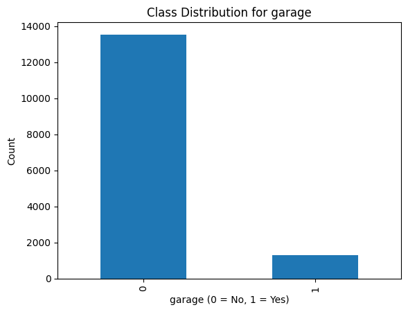

```
Class distribution for street:
street
0    8017
1    6803
Name: count, dtype: int64
```

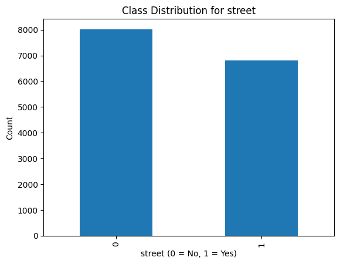

```
Class distribution for lot:
lot
0    7704
1    7116
Name: count, dtype: int64
```

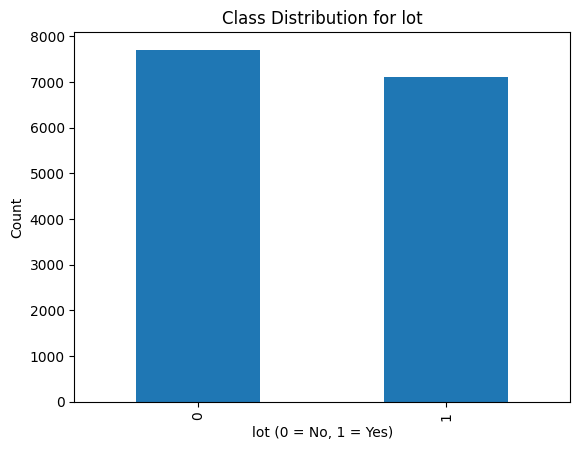

```
Class distribution for valet:
valet
0    13857
1      963
Name: count, dtype: int64
```

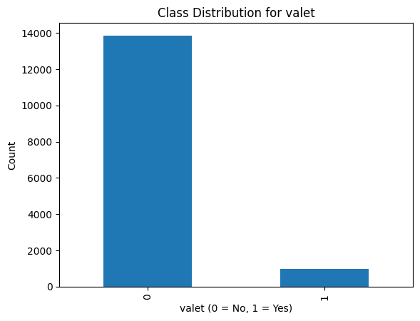

```python
for column in target_parking:
    print(f"Class distribution for {column}:")
    print(y_train_parking[column].value_counts())
    y_train_parking[column].value_counts().plot(kind='bar')
    plt.title(f"Class Distribution for {column}")
    plt.xlabel(f'{column} (0 = No, 1 = Yes)')
    plt.ylabel('Count')
    plt.show()
```

```
Class distribution for validated parking:
validated
0    14348
1      472
Name: count, dtype: int64
```

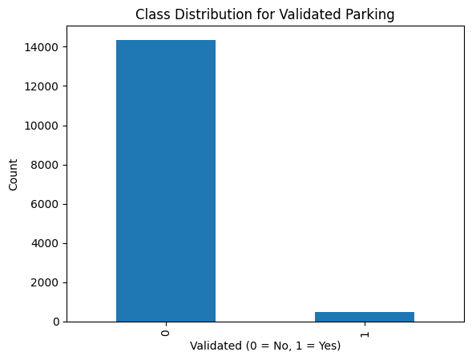

```python
print("Class distribution for validated parking:")
print(y_train_validated.value_counts())
y_train_validated.value_counts().plot(kind='bar')
plt.title("Class Distribution for Validated Parking")
plt.xlabel('Validated (0 = No, 1 = Yes)')
plt.ylabel('Count')
plt.show()
```

As we can see frm the above charts that there is clearly a class imbalance so applying smot to hndle that.

```python
from imblearn.over_sampling import SMOTE
from sklearn.model_selection import train_test_split

target_parking = ['garage', 'street', 'lot', 'valet']
target_validated = 'validated'

X = Data.drop(columns=target_parking + [target_validated, 'business_id', 'address'])
smote = SMOTE(random_state=42)
resampled_data = {}

for target in target_parking:
    print(f"Applying SMOTE for {target}...")

    X_train, X_test, y_train, y_test = train_test_split(X, Data[target], test_size=0.4, random_state=42)

    X_train_resampled, y_train_resampled = smote.fit_resample(X_train, y_train)

    resampled_data[target] = {
        "X_train_resampled": X_train_resampled,
        "y_train_resampled": y_train_resampled,
        "X_test": X_test,
        "y_test": y_test
    }

    print(f"SMOTE applied for {target}. Resampled data shape: {X_train_resampled.shape}")

print("Applying SMOTE for validated parking...")

X_train_validated, X_test_validated, y_train_validated, y_test_validated = train_test_split(X, Data[target_validated], test_size=0.2, random_state=42)

X_train_validated_resampled, y_train_validated_resampled = smote.fit_resample(X_train_validated, y_train_validated)

resampled_data['validated'] = {
    "X_train_resampled": X_train_validated_resampled,
    "y_train_resampled": y_train_validated_resampled,
    "X_test": X_test_validated,
    "y_test": y_test_validated
}

print(f"SMOTE applied for validated parking. Resampled data shape: {X_train_validated_resampled.shape}")
```

```
Applying SMOTE for garage...
SMOTE applied for garage. Resampled data shape: (20310, 4217)
Applying SMOTE for street...
SMOTE applied for street. Resampled data shape: (12108, 4217)
Applying SMOTE for lot...
SMOTE applied for lot. Resampled data shape: (11582, 4217)
Applying SMOTE for valet...
SMOTE applied for valet. Resampled data shape: (20856, 4217)
Applying SMOTE for validated parking...
SMOTE applied for validated parking. Resampled data shape: (28696, 4217)
```

Applied smote only to the training data in order to avoid data leakage.

Training the *XGBoost Classifier* and obtaining the metrics along with confusion matrix, AUC, Roc for both training and test data.

```
Training XGBoost for garage...
```

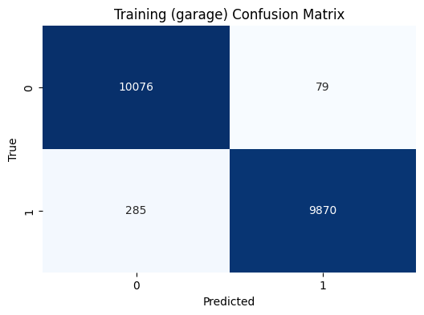

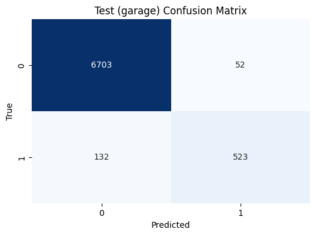

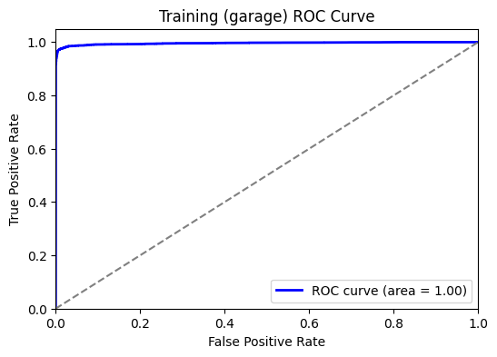

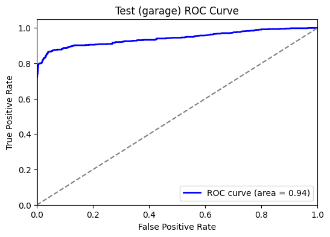

```
Training Accuracy for garage: 0.9820777941900541
Training Classification Report for garage:
              precision    recall  f1-score   support

           0       0.97      0.99      0.98     10155
           1       0.99      0.97      0.98     10155

    accuracy                           0.98     20310
   macro avg       0.98      0.98      0.98     20310
weighted avg       0.98      0.98      0.98     20310

Test Accuracy for garage: 0.9751686909581646
Test Classification Report for garage:
              precision    recall  f1-score   support

           0       0.98      0.99      0.99      6755
           1       0.91      0.80      0.85       655

    accuracy                           0.98      7410
   macro avg       0.95      0.90      0.92      7410
weighted avg       0.97      0.98      0.97      7410

Training XGBoost for street...
```

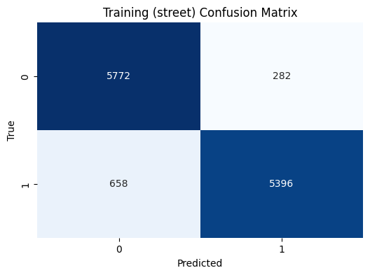

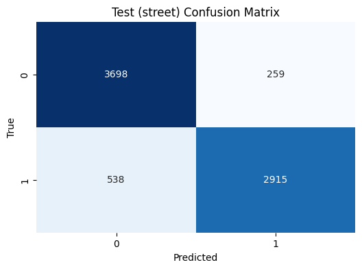

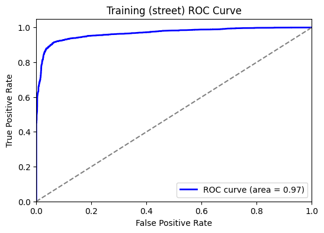

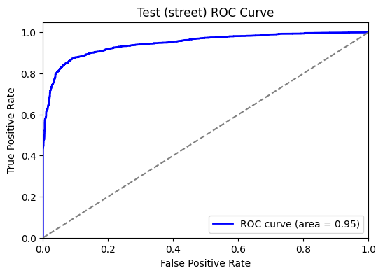

```
Training Accuracy for street: 0.9223653782623059
Training Classification Report for street:
              precision    recall  f1-score   support

           0       0.90      0.95      0.92      6054
           1       0.95      0.89      0.92      6054

    accuracy                           0.92     12108
   macro avg       0.92      0.92      0.92     12108
weighted avg       0.92      0.92      0.92     12108

Test Accuracy for street: 0.892442645074224
Test Classification Report for street:
              precision    recall  f1-score   support

           0       0.87      0.93      0.90      3957
           1       0.92      0.84      0.88      3453

    accuracy                           0.89      7410
   macro avg       0.90      0.89      0.89      7410
weighted avg       0.89      0.89      0.89      7410

Training XGBoost for lot...
```

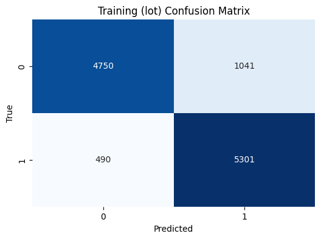

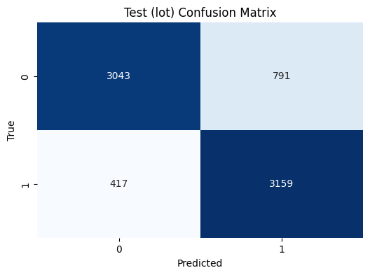

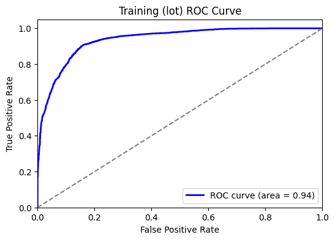

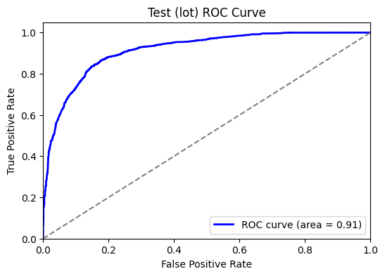

```
Training Accuracy for lot: 0.8678121222586772
Training Classification Report for lot:
              precision    recall  f1-score   support

           0       0.91      0.82      0.86      5791
           1       0.84      0.92      0.87      5791

    accuracy                           0.87     11582
   macro avg       0.87      0.87      0.87     11582
weighted avg       0.87      0.87      0.87     11582

Test Accuracy for lot: 0.8369770580296896
Test Classification Report for lot:
              precision    recall  f1-score   support

           0       0.88      0.79      0.83      3834
           1       0.80      0.88      0.84      3576

    accuracy                           0.84      7410
   macro avg       0.84      0.84      0.84      7410
weighted avg       0.84      0.84      0.84      7410

Training XGBoost for valet...
```

[8 more figures not shown]

```
Training Accuracy for validated parking: 0.9993378868134931
Training Classification Report for validated parking:
              precision    recall  f1-score   support

           0       1.00      1.00      1.00     14348
           1       1.00      1.00      1.00     14348

    accuracy                           1.00     28696
   macro avg       1.00      1.00      1.00     28696
weighted avg       1.00      1.00      1.00     28696

Test Accuracy for validated parking: 0.9975708502024292
Test Classification Report for validated parking:
              precision    recall  f1-score   support

           0       1.00      1.00      1.00      3578
           1       1.00      0.93      0.96       127

    accuracy                           1.00      3705
   macro avg       1.00      0.96      0.98      3705
weighted avg       1.00      1.00      1.00      3705
```

```python
def plot_confusion_matrix(y_true, y_pred, title):
    cm = confusion_matrix(y_true, y_pred)
    plt.figure(figsize=(6, 4))
    sns.heatmap(cm, annot=True, fmt='d', cmap='Blues', cbar=False)
    plt.title(f'{title} Confusion Matrix')
    plt.xlabel('Predicted')
    plt.ylabel('True')
    plt.show()

def plot_roc_curve_custom(model, X, y_true, title):
    y_prob = model.predict_proba(X)[:, 1]  # Get the probability of the positive class
    fpr, tpr, thresholds = roc_curve(y_true, y_prob)
    roc_auc = auc(fpr, tpr)

    plt.figure(figsize=(6, 4))
    plt.plot(fpr, tpr, color='blue', lw=2, label=f'ROC curve (area = {roc_auc:.2f})')
    plt.plot([0, 1], [0, 1], color='gray', linestyle='--')
    plt.xlim([0.0, 1.0])
    plt.ylim([0.0, 1.05])
    plt.xlabel('False Positive Rate')
    plt.ylabel('True Positive Rate')
    plt.title(f'{title} ROC Curve')
    plt.legend(loc='lower right')
    plt.show()

for target in target_parking:
    print(f"Training XGBoost for {target}...")

    X_train_resampled = resampled_data[target]['X_train_resampled']
    y_train_resampled = resampled_data[target]['y_train_resampled']
    X_test = resampled_data[target]['X_test']
    y_test = resampled_data[target]['y_test']

    xgb_model = xgb.XGBClassifier(use_label_encoder=False, eval_metric='logloss', random_state=42)
    xgb_model.fit(X_train_resampled, y_train_resampled)

    y_train_pred = xgb_model.predict(X_train_resampled)
    train_accuracy = accuracy_score(y_train_resampled, y_train_pred)
    train_report = classification_report(y_train_resampled, y_train_pred)

    y_test_pred = xgb_model.predict(X_test)
    test_accuracy = accuracy_score(y_test, y_test_pred)
    test_report = classification_report(y_test, y_test_pred)

    plot_confusion_matrix(y_train_resampled, y_train_pred, f'Training ({target})')
    plot_confusion_matrix(y_test, y_test_pred, f'Test ({target})')

    plot_roc_curve_custom(xgb_model, X_train_resampled, y_train_resampled, f'Training ({target})')
    plot_roc_curve_custom(xgb_model, X_test, y_test, f'Test ({target})')

    xgboost_results[target] = {
        "model": xgb_model,
        "train_accuracy": train_accuracy,
        "train_classification_report": train_report,
        "test_accuracy": test_accuracy,
        "test_classification_report": test_report
    }

    print(f"Training Accuracy for {target}: {train_accuracy}")
    print(f"Training Classification Report for {target}:\n{train_report}")

    print(f"Test Accuracy for {target}: {test_accuracy}")
    print(f"Test Classification Report for {target}:\n{test_report}")

print("Training XGBoost for validated parking...")

X_train_validated_resampled = resampled_data['validated']['X_train_resampled']
y_train_validated_resampled = resampled_data['validated']['y_train_resampled']
X_test_validated = resampled_data['validated']['X_test']
y_test_validated = resampled_data['validated']['y_test']

xgb_model_validated = xgb.XGBClassifier(use_label_encoder=False, eval_metric='logloss', random_state=42)
xgb_model_validated.fit(X_train_validated_resampled, y_train_validated_resampled)

y_train_validated_pred = xgb_model_validated.predict(X_train_validated_resampled)
train_validated_accuracy = accuracy_score(y_train_validated_resampled, y_train_validated_pred)
train_validated_report = classification_report(y_train_validated_resampled, y_train_validated_pred)

y_test_validated_pred = xgb_model_validated.predict(X_test_validated)
test_validated_accuracy = accuracy_score(y_test_validated, y_test_validated_pred)
test_validated_report = classification_report(y_test_validated, y_test_validated_pred)

plot_confusion_matrix(y_train_validated_resampled, y_train_validated_pred, f'Training (validated parking)')
plot_confusion_matrix(y_test_validated, y_test_validated_pred, f'Test (validated parking)')
plot_roc_curve_custom(xgb_model_validated, X_train_validated_resampled, y_train_validated_resampled, 'Training (validated parking)')
plot_roc_curve_custom(xgb_model_validated, X_test_validated, y_test_validated, 'Test (validated parking)')

xgboost_results['validated'] = {
    "model": xgb_model_validated,
    "train_accuracy": train_validated_accuracy,
    "train_classification_report": train_validated_report,
    "test_accuracy": test_validated_accuracy,
    "test_classification_report": test_validated_report
}

print(f"Training Accuracy for validated parking: {train_validated_accuracy}")
print(f"Training Classification Report for validated parking:\n{train_validated_report}")
print(f"Test Accuracy for validated parking: {test_validated_accuracy}")
print(f"Test Classification Report for validated parking:\n{test_validated_report}")
```

```
Training DNN for garage...
635/635 ━━━━━━━━━━━━━━━━━━━━ 10s 9ms/step - accuracy: 0.8650 - loss: 0.3121 - val_accuracy: 0.9903 - val_loss: 0.0455
635/635 ━━━━━━━━━━━━━━━━━━━━ 4s 7ms/step - accuracy: 0.9974 - loss: 0.0079 - val_accuracy: 0.9919 - val_loss: 0.0453
635/635 ━━━━━━━━━━━━━━━━━━━━ 7s 9ms/step - accuracy: 0.9988 - loss: 0.0033 - val_accuracy: 0.9915 - val_loss: 0.0493
635/635 ━━━━━━━━━━━━━━━━━━━━ 4s 6ms/step - accuracy: 0.9993 - loss: 0.0024 - val_accuracy: 0.9788 - val_loss: 0.0644
635/635 ━━━━━━━━━━━━━━━━━━━━ 4s 7ms/step - accuracy: 0.9988 - loss: 0.0030 - val_accuracy: 0.9893 - val_loss: 0.0557
635/635 ━━━━━━━━━━━━━━━━━━━━ 2s 4ms/step
232/232 ━━━━━━━━━━━━━━━━━━━━ 1s 2ms/step
Training Accuracy for garage: 0.9992122107336288
Training Classification Report for garage:
              precision    recall  f1-score   support

           0       1.00      1.00      1.00     10155
           1       1.00      1.00      1.00     10155

    accuracy                           1.00     20310
   macro avg       1.00      1.00      1.00     20310
weighted avg       1.00      1.00      1.00     20310

Test Accuracy for garage: 0.9893387314439946
Test Classification Report for garage:
              precision    recall  f1-score   support

           0       0.99      0.99      0.99      6755
           1       0.94      0.94      0.94       655

    accuracy                           0.99      7410
   macro avg       0.97      0.97      0.97      7410
weighted avg       0.99      0.99      0.99      7410
```

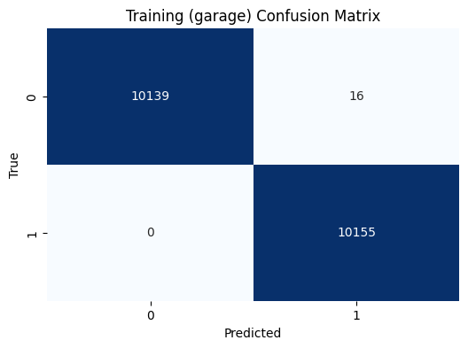

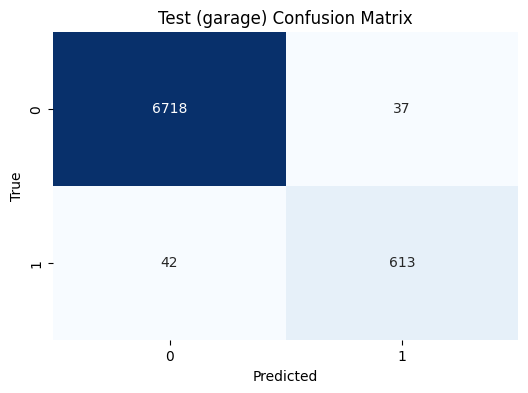

```
635/635 ━━━━━━━━━━━━━━━━━━━━ 1s 2ms/step
```

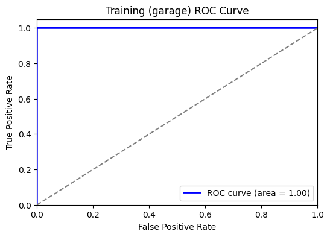

```
232/232 ━━━━━━━━━━━━━━━━━━━━ 1s 4ms/step
```

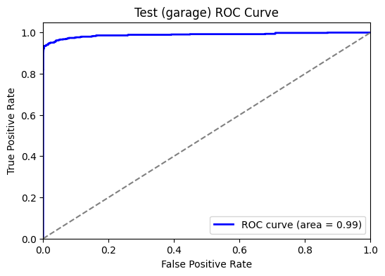

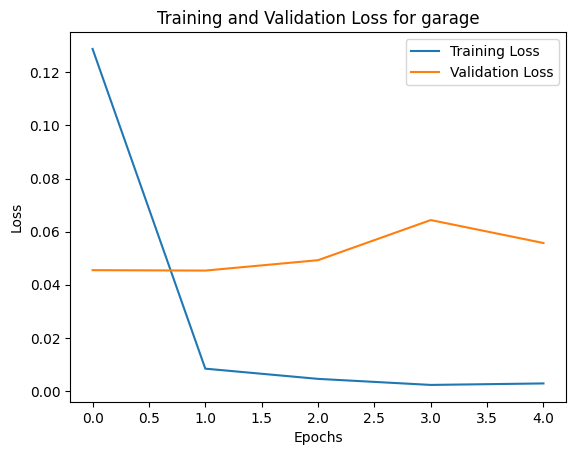

```
Training DNN for street...
379/379 ━━━━━━━━━━━━━━━━━━━━ 5s 9ms/step - accuracy: 0.7186 - loss: 0.5211 - val_accuracy: 0.9386 - val_loss: 0.1653
379/379 ━━━━━━━━━━━━━━━━━━━━ 5s 8ms/step - accuracy: 0.9725 - loss: 0.0848 - val_accuracy: 0.9501 - val_loss: 0.1378
379/379 ━━━━━━━━━━━━━━━━━━━━ 5s 13ms/step - accuracy: 0.9925 - loss: 0.0274 - val_accuracy: 0.9615 - val_loss: 0.1129
379/379 ━━━━━━━━━━━━━━━━━━━━ 3s 7ms/step - accuracy: 0.9957 - loss: 0.0133 - val_accuracy: 0.9618 - val_loss: 0.1170
379/379 ━━━━━━━━━━━━━━━━━━━━ 5s 8ms/step - accuracy: 0.9982 - loss: 0.0085 - val_accuracy: 0.9634 - val_loss: 0.1277
379/379 ━━━━━━━━━━━━━━━━━━━━ 2s 4ms/step
232/232 ━━━━━━━━━━━━━━━━━━━━ 1s 2ms/step
Training Accuracy for street: 0.9982656095143707
Training Classification Report for street:
              precision    recall  f1-score   support

           0       1.00      1.00      1.00      6054
           1       1.00      1.00      1.00      6054

    accuracy                           1.00     12108
   macro avg       1.00      1.00      1.00     12108
weighted avg       1.00      1.00      1.00     12108

Test Accuracy for street: 0.9634278002699055
Test Classification Report for street:
              precision    recall  f1-score   support

           0       0.97      0.97      0.97      3957
           1       0.96      0.96      0.96      3453

    accuracy                           0.96      7410
   macro avg       0.96      0.96      0.96      7410
weighted avg       0.96      0.96      0.96      7410
```

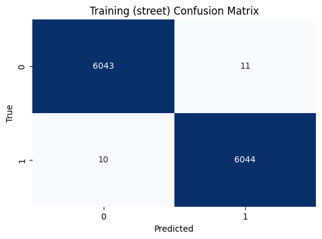

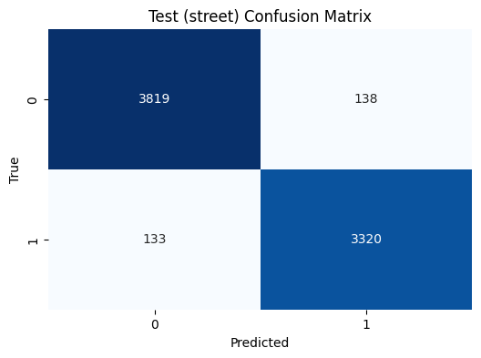

```
379/379 ━━━━━━━━━━━━━━━━━━━━ 1s 2ms/step
```

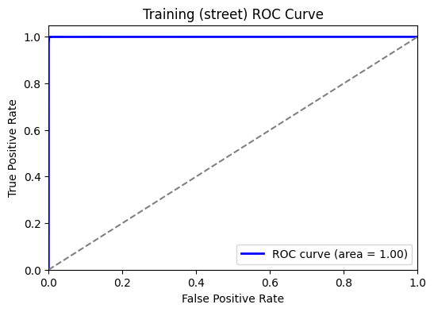

```
232/232 ━━━━━━━━━━━━━━━━━━━━ 1s 2ms/step
```

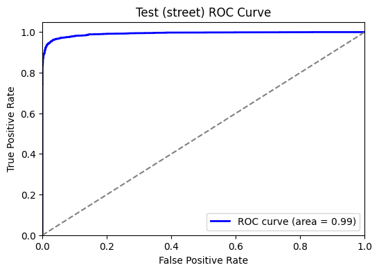

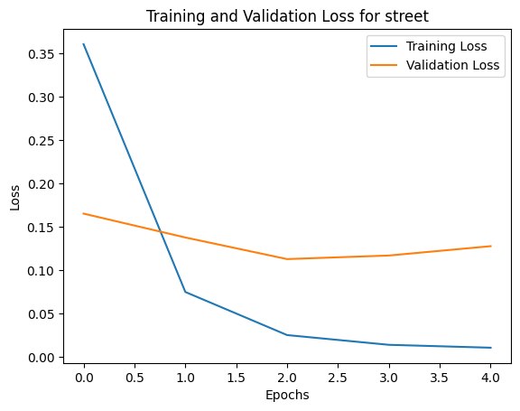

```
Training DNN for lot...
362/362 ━━━━━━━━━━━━━━━━━━━━ 6s 13ms/step - accuracy: 0.7104 - loss: 0.5587 - val_accuracy: 0.8966 - val_loss: 0.2369
362/362 ━━━━━━━━━━━━━━━━━━━━ 4s 8ms/step - accuracy: 0.9594 - loss: 0.1158 - val_accuracy: 0.9224 - val_loss: 0.1922
362/362 ━━━━━━━━━━━━━━━━━━━━ 3s 8ms/step - accuracy: 0.9854 - loss: 0.0426 - val_accuracy: 0.9238 - val_loss: 0.2039
362/362 ━━━━━━━━━━━━━━━━━━━━ 5s 9ms/step - accuracy: 0.9909 - loss: 0.0274 - val_accuracy: 0.9277 - val_loss: 0.1997
362/362 ━━━━━━━━━━━━━━━━━━━━ 5s 8ms/step - accuracy: 0.9931 - loss: 0.0207 - val_accuracy: 0.9248 - val_loss: 0.2410
362/362 ━━━━━━━━━━━━━━━━━━━━ 1s 3ms/step
232/232 ━━━━━━━━━━━━━━━━━━━━ 1s 2ms/step
Training Accuracy for lot: 0.9949922293213608
Training Classification Report for lot:
              precision    recall  f1-score   support

           0       1.00      0.99      0.99      5791
           1       0.99      1.00      1.00      5791

    accuracy                           0.99     11582
   macro avg       0.99      0.99      0.99     11582
weighted avg       0.99      0.99      0.99     11582

Test Accuracy for lot: 0.9248313090418353
Test Classification Report for lot:
              precision    recall  f1-score   support

           0       0.93      0.92      0.93      3834
           1       0.92      0.93      0.92      3576

    accuracy                           0.92      7410
   macro avg       0.92      0.92      0.92      7410
weighted avg       0.92      0.92      0.92      7410
```

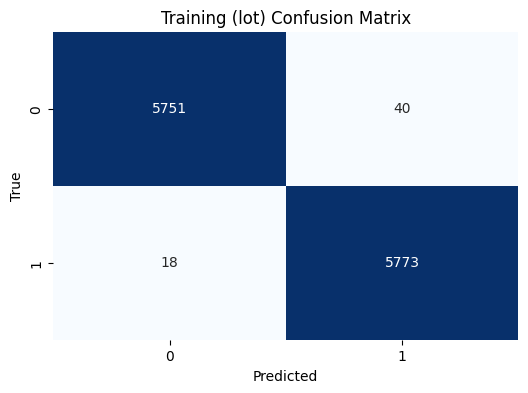

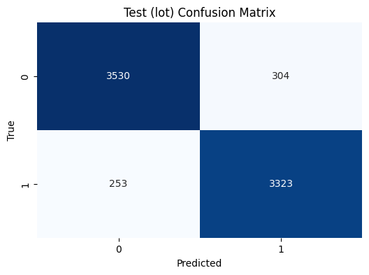

```
362/362 ━━━━━━━━━━━━━━━━━━━━ 1s 4ms/step
```

[13 more figures not shown]

```python
import tensorflow as tf

# Function to plot confusion matrix
def plot_confusion_matrix(y_true, y_pred, title):
    cm = confusion_matrix(y_true, y_pred)
    plt.figure(figsize=(6, 4))
    sns.heatmap(cm, annot=True, fmt='d', cmap='Blues', cbar=False)
    plt.title(f'{title} Confusion Matrix')
    plt.xlabel('Predicted')
    plt.ylabel('True')
    plt.show()

# Function to plot ROC curve
def plot_roc_curve_custom(model, X, y_true, title):
    y_prob = model.predict(X).ravel()  # Get the probability of the positive class
    fpr, tpr, thresholds = roc_curve(y_true, y_prob)
    roc_auc = auc(fpr, tpr)

    plt.figure(figsize=(6, 4))
    plt.plot(fpr, tpr, color='blue', lw=2, label=f'ROC curve (area = {roc_auc:.2f})')
    plt.plot([0, 1], [0, 1], color='gray', linestyle='--')
    plt.xlim([0.0, 1.0])
    plt.ylim([0.0, 1.05])
    plt.xlabel('False Positive Rate')
    plt.ylabel('True Positive Rate')
    plt.title(f'{title} ROC Curve')
    plt.legend(loc='lower right')
    plt.show()

# Build a DNN model
def build_dnn_model(input_shape):
    model = tf.keras.Sequential()
    model.add(tf.keras.layers.InputLayer(input_shape=(input_shape,)))

    model.add(tf.keras.layers.Dense(64, activation='relu'))
    model.add(tf.keras.layers.Dense(32, activation='relu'))
    model.add(tf.keras.layers.Dense(16, activation='relu'))

    model.add(tf.keras.layers.Dense(1, activation='sigmoid'))  # Sigmoid for binary classification


    model.compile(optimizer='adam', loss='binary_crossentropy', metrics=['accuracy'])
    return model

dnn_results = {}

for target in target_parking + [target_validated]:
    print(f"Training DNN for {target}...")

    # Get the resampled training data from SMOTE
    X_train_resampled = resampled_data[target]['X_train_resampled']
    y_train_resampled = resampled_data[target]['y_train_resampled']
    X_test = resampled_data[target]['X_test']
    y_test = resampled_data[target]['y_test']

    input_shape = X_train_resampled.shape[1]
    model = build_dnn_model(input_shape)

    history = model.fit(X_train_resampled, y_train_resampled, epochs=5, batch_size=32, validation_data=(X_test, y_test), verbose=1)

    # Step 1: Evaluate on the training set
    y_train_pred_prob = model.predict(X_train_resampled)
    y_train_pred = (y_train_pred_prob > 0.5).astype("int32")
    train_accuracy = accuracy_score(y_train_resampled, y_train_pred)
    train_report = classification_report(y_train_resampled, y_train_pred)

    # Step 2: Evaluate on the test set
    y_test_pred_prob = model.predict(X_test)
    y_test_pred = (y_test_pred_prob > 0.5).astype("int32")
    test_accuracy = accuracy_score(y_test, y_test_pred)
    test_report = classification_report(y_test, y_test_pred)

    dnn_results[target] = {
        "model": model,
        "train_accuracy": train_accuracy,
        "train_classification_report": train_report,
        "test_accuracy": test_accuracy,
        "test_classification_report": test_report,
        "history": history
    }

    print(f"Training Accuracy for {target}: {train_accuracy}")
    print(f"Training Classification Report for {target}:\n{train_report}")
    print(f"Test Accuracy for {target}: {test_accuracy}")
    print(f"Test Classification Report for {target}:\n{test_report}")

    plot_confusion_matrix(y_train_resampled, y_train_pred, f'Training ({target})')
    plot_confusion_matrix(y_test, y_test_pred, f'Test ({target})')

    plot_roc_curve_custom(model, X_train_resampled, y_train_resampled, f'Training ({target})')
    plot_roc_curve_custom(model, X_test, y_test, f'Test ({target})')

    plt.plot(history.history['loss'], label='Training Loss')
    plt.plot(history.history['val_loss'], label='Validation Loss')
    plt.title(f'Training and Validation Loss for {target}')
    plt.xlabel('Epochs')
    plt.ylabel('Loss')
    plt.legend()
    plt.show()
```